# **Analysis of Heart Disease Mortality Data**

#### **Mean and Standard Deviation of Heart Disease Mortality Rate**

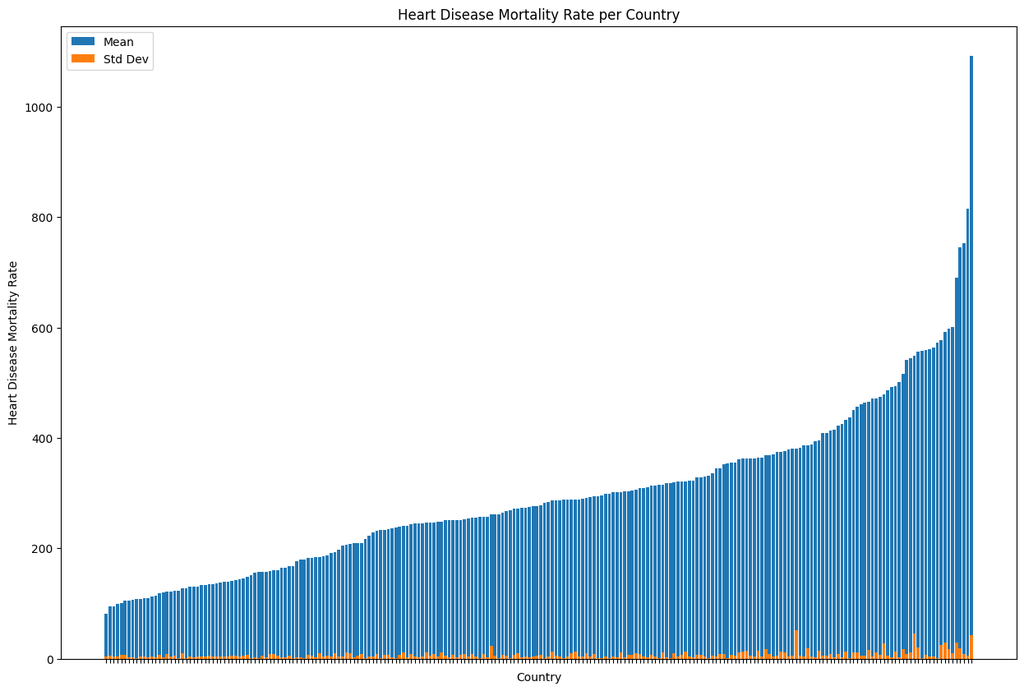

```python
# Label the x and y axes and set the size of the plot figure
plt.figure(figsize=(15, 10))
plt.title('Heart Disease Mortality Rate per Country')
plt.xlabel('Country')
plt.ylabel('Heart Disease Mortality Rate')

# Create two data frames that compute the mean and standard deviation of the heart disease mortality rate for each country
# and merge these values into 1 table
heart_disease_mortality_rate_mean = heart_disease_death_rates.groupby('Country', as_index=False)['Heart Disease Mortality Rate (Deaths per 100K people)'].mean()
heart_disease_mortality_rate_std = heart_disease_death_rates.groupby('Country', as_index=False)['Heart Disease Mortality Rate (Deaths per 100K people)'].std()
heart_disease_mortality_rate = heart_disease_mortality_rate_mean.merge(heart_disease_mortality_rate_std, how="outer", left_on = ["Country"],  right_on = ["Country"])

# Rename columns in table to have appropriate names
heart_disease_mortality_rate = heart_disease_mortality_rate.rename(columns={"Heart Disease Mortality Rate (Deaths per 100K people)_x": "Mean", "Heart Disease Mortality Rate (Deaths per 100K people)_y": "Std Dev"})
heart_disease_mortality_rate

# Sort heart disease mortality df with mean and std dev per country based on mean
heart_disease_mortality_rate.sort_values('Mean', inplace=True)

# Plot the heart disease mortality rate mean and std dev bar series onto 1 graph
plt.bar(x=heart_disease_mortality_rate['Country'], height=heart_disease_mortality_rate['Mean'], tick_label='')
plt.bar(x=heart_disease_mortality_rate['Country'], height=heart_disease_mortality_rate['Std Dev'], tick_label='')

# Create legend that shows heart disease mortality rate mean and standard deviation by color
plt.legend(['Mean', 'Std Dev'], loc='upper left')

plt.show()
```

## **Analysis, Hypothesis Testing & ML**

#### **Hypothesis Testing & Linear Regression**

[figure not shown]

During the data visualization section, we noticed that there are significant outliers in the Type 1 and 2 diabetes and low physcial activities DALYs feature data. Since this will create a noticeable bias in the prediction, we decided to drop the three features and move forward to the hypothesis testing section. First, we will perform min-max normalization to each feature. We are choosing this over z-standardization because our features have different ranges and we want them to have the same scale and z-standardization made no major differences in the performance. We will also include an 80-10-10 training-validation-test split for the data (models this will be applied to will be indicated in each section). Next, we will perform a z-test on all the data first using the probability of the f-statistic from OLS (ordinary least squares regression) to confirm whether multivariate linear regression is a good fit for the data (the linked [article](https://www.geeksforgeeks.org/ordinary-least-squares-ols-using-statsmodels/) shows an example of how we performed the z-test). In this case, we see the p-value of the F-statistic is 0.568, which is not less than 0.05 or close to 0 and a strong indicator that linear regression may not be the best model for our data as it is likely that the null hypothesis of no relationship between our features and heart disease mortality rate is true. To verify this though, let's try running the linear regression model using sklearn on all the data and check the feature p-values and accuracy score (coefficient of determination).

```python
#Dropping the columns
cols_to_drop = ['Type 1 Deaths', 'Type 2 Deaths', 'Low Physical Activity DALYs']
heart_disease_death_rates = heart_disease_death_rates.drop(columns = cols_to_drop)

#Perform min-max normalization on the data
#columns to normalized excluding country and Year
columns_to_normalized = heart_disease_death_rates.columns[2:]

#Getting the min and max values for each feature
scaler = MinMaxScaler()

#Performing min-max normalization
heart_disease_death_rates[columns_to_normalized] = scaler.fit_transform(heart_disease_death_rates[columns_to_normalized])

#Renaming the columns to shorten the names
heart_disease_death_rates.rename(columns = {'% of population with anxiety disorders':'Anxiety','Mean BMI':'BMI','Mean HDL Cholesterol':'Cholesterol','Spirits Consumption':'Alcohol','Smoking Death Percentage':'Smoking','Raised Blood Pressure Percentage':'Blood Pressure','Healthcare Expenditure (% of GDP)':'Healthcare Exp','% of overweight adults':'Overweight','Heart Disease Mortality Rate (Deaths per 100K people)':'Heart Disease Mortality Rate'}, inplace= True)

display(heart_disease_death_rates)

# Extract independent variables (features) and dependent variable (target)
X = heart_disease_death_rates.drop(columns=['Country', 'Heart Disease Mortality Rate'])
y = heart_disease_death_rates['Heart Disease Mortality Rate']

# Split data into training, validation, and test samples using 80-10-10 split
trainX, tempX, trainY, tempY = train_test_split(X, y, test_size = 0.2, random_state = 42)
validX, testX, validY, testY = train_test_split(X, y, test_size = 0.5, random_state = 42)
```

|  | Country | Year | Anxiety | BMI | Cholesterol | Alcohol | Smoking | Blood Pressure | Healthcare Exp | Overweight | Heart Disease Mortality Rate |
| --- | --- | --- | --- | --- | --- | --- | --- | --- | --- | --- | --- |
| 0 | Afghanistan | 2012 | 0.460098 | 0.338651 | 0.375000 | 0.141140 | 0.242707 | 0.870536 | 0.346736 | 0.063361 | 0.508701 |
| 1 | Afghanistan | 2013 | 0.464530 | 0.345265 | 0.375000 | 0.137901 | 0.247974 | 0.870536 | 0.394256 | 0.071625 | 0.498590 |
| 2 | Afghanistan | 2014 | 0.468789 | 0.358492 | 0.375000 | 0.000000 | 0.247974 | 0.875000 | 0.431854 | 0.079890 | 0.491881 |
| 3 | Afghanistan | 2015 | 0.471569 | 0.365105 | 0.375000 | 0.133309 | 0.249190 | 0.875000 | 0.462141 | 0.088154 | 0.488564 |
| 4 | Afghanistan | 2016 | 0.472390 | 0.371719 | 0.375000 | 0.000000 | 0.250810 | 0.834821 | 0.551436 | 0.097796 | 0.483462 |
| ... | ... | ... | ... | ... | ... | ... | ... | ... | ... | ... | ... |
| 1363 | Zimbabwe | 2013 | 0.359238 | 0.424081 | 0.461373 | 0.179645 | 0.294976 | 0.593624 | 0.256924 | 0.452251 | 0.238931 |
| 1364 | Zimbabwe | 2014 | 0.360261 | 0.419397 | 0.462015 | 0.168416 | 0.300243 | 0.593624 | 0.262536 | 0.452251 | 0.238198 |
| 1365 | Zimbabwe | 2015 | 0.360988 | 0.421819 | 0.460731 | 0.166924 | 0.305916 | 0.593624 | 0.265709 | 0.452251 | 0.237249 |
| 1366 | Zimbabwe | 2016 | 0.361265 | 0.419921 | 0.463940 | 0.165311 | 0.310778 | 0.593624 | 0.267524 | 0.452251 | 0.235435 |
| 1367 | Zimbabwe | 2017 | 0.361364 | 0.414507 | 0.463940 | 0.163366 | 0.314425 | 0.593624 | 0.263618 | 0.452251 | 0.232879 |

1368 rows × 11 columns

```python
# Do a test for whether linear regression is a good fit for the data by using OLS and looking at prob of f-statistic in model summary
formula = "Q('Heart Disease Mortality Rate') ~ Year + Anxiety + BMI + Cholesterol + Alcohol + Smoking + Q('Blood Pressure') + Q('Healthcare Exp') + Overweight"
reg = smf.ols(formula = formula, data = heart_disease_death_rates).fit()
print(reg.summary())
```

```
                                    OLS Regression Results
=============================================================================================
Dep. Variable:     Q('Heart Disease Mortality Rate')   R-squared:                       0.006
Model:                                           OLS   Adj. R-squared:                 -0.001
Method:                                Least Squares   F-statistic:                    0.8517
Date:                               Fri, 18 Aug 2023   Prob (F-statistic):              0.568
Time:                                       13:18:28   Log-Likelihood:                 777.04
No. Observations:                               1368   AIC:                            -1534.
Df Residuals:                                   1358   BIC:                            -1482.
Df Model:                                          9
Covariance Type:                           nonrobust
=======================================================================================
                          coef    std err          t      P>|t|      [0.025      0.975]
---------------------------------------------------------------------------------------
Intercept               5.1792      4.398      1.178      0.239      -3.448      13.807
Year                   -0.0025      0.002     -1.131      0.258      -0.007       0.002
Anxiety                 0.0167      0.023      0.727      0.467      -0.028       0.062
BMI                    -0.0209      0.022     -0.953      0.341      -0.064       0.022
Cholesterol             0.0307      0.020      1.516      0.130      -0.009       0.070
Alcohol                -0.0499      0.026     -1.946      0.052      -0.100       0.000
Smoking                 0.0023      0.016      0.145      0.884      -0.028       0.033
Q('Blood Pressure')     0.0041      0.026      0.158      0.874      -0.046       0.054
Q('Healthcare Exp')    -0.0179      0.029     -0.610      0.542      -0.076       0.040
Overweight              0.0006      0.023      0.026      0.980      -0.044       0.046
==============================================================================
Omnibus:                      397.011   Durbin-Watson:                   0.340
Prob(Omnibus):                  0.000   Jarque-Bera (JB):             1335.219
Skew:                           1.412   Prob(JB):                    1.15e-290
Kurtosis:                       6.931   Cond. No.                     2.38e+06
==============================================================================

Notes:
[1] Standard Errors assume that the covariance matrix of the errors is correctly specified.
[2] The condition number is large, 2.38e+06. This might indicate that there are
strong multicollinearity or other numerical problems.
```

One more thing we can do is run a linear regression model on randomly sampled training and test data (80-20 split in this case, not including validation data) to get the MSE and accuracy score (R^2) for the test data. Although the MSE (0.017) is very low, the R^2 score is -0.02, which means this linear regression model's predictions don't match the expected heart disease mortality rates very well. In the end, all this evidence confirms our assumption that multivariate linear regression was not the best model for the data. We should test some other models.

```
Feature: Year
P-value: 0.2997403454148443

Feature: Anxiety
P-value: 0.7329907670518356

Feature: BMI
P-value: 0.28469253882980683

Feature: Cholesterol
P-value: 0.3230816945881244

Feature: Alcohol
P-value: 0.12618638983138056

Feature: Smoking
P-value: 0.8348375778233341

Feature: Blood Pressure
P-value: 0.7269949529751873

Feature: Healthcare Exp
P-value: 0.7550205891418605

Feature: Overweight
P-value: 0.505752996291276

Linear Regression Model Score for Full Data (R^2):  0.005612852135620683
```

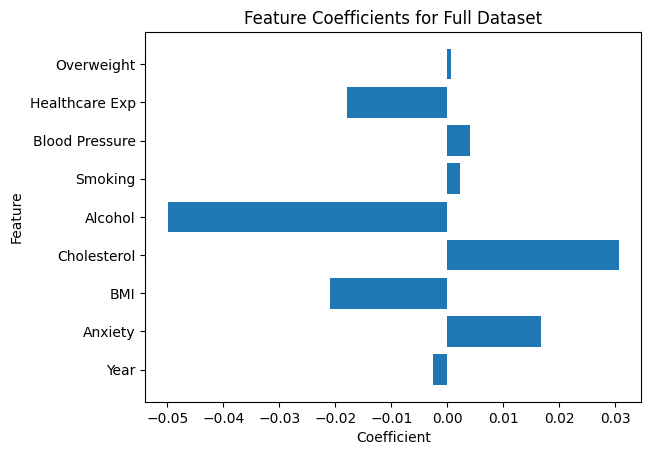

```
Linear Regression Model MSE Score on Test Data:  0.017842903366512217
Linear Regression Model R2 Score on Test Data:  -0.021220160172261027
```

```python
# Create a linear regression model for all the data
lin_reg_model = LinearRegression()

# Fit the model to all the dat
lin_reg_model.fit(X, y)

# Perform the F-test for all the data
f_values, p_values = f_regression(X, y)

# Display  p-values for each feature
for i, feature in enumerate(X.columns):
    print(f"Feature: {feature}")
    print(f"P-value: {p_values[i]}\n")

# Show lin reg model score (coefficient of determination)
print("Linear Regression Model Score for Full Data (R^2): ", lin_reg_model.score(X, y))

# Stacked bar chart that plots feature coefficients to show how they are correlated with heart disease mortality rate
# Set bar chart size and axis labels
plt.figure()
plt.title('Feature Coefficients for Full Dataset')
plt.xlabel('Coefficient')
plt.ylabel('Feature')

# Create horizontal bar graph with features on the y-axis and the feature coefficient as a width along the x axis
plt.barh(y=X.columns, width=lin_reg_model.coef_)
plt.show()

# Create linear regression model that will fit on randomly sampled training data and then make predictions on test data so we can measure MSE & R^2 score
# to see how well lin reg performs (explains) on the data
lin_reg_model2 = LinearRegression()
lin_reg_model2.fit(trainX, trainY)
linTestX = tempX
linTestY = tempY
yTestPred = lin_reg_model2.predict(linTestX)
linMSE = mean_squared_error(linTestY, yTestPred)
lin_r2 = r2_score(linTestY, yTestPred)
print("Linear Regression Model MSE Score on Test Data: ", linMSE)
print("Linear Regression Model R2 Score on Test Data: ", lin_r2)
```

#### **Random Forests & Feature Importance**

[figure not shown]

One model we can explore is a random forest, which is an ensemble model that uses bootstrapping to create multiple copies of a dataset through random sampling by replacement and builds a decision tree upon each dataset. It will also pass in any testing observation to all those decision trees and whatever output prediction has the majority vote among all those decision trees will be returned as the predicted value for that observation. In our case, random forest would build an ensemble of decision trees to predict heart disease mortality rate. We will fit a random forest regressor on the data set to predict the heart disease mortality rate and measure its score to determine if it is the optimal model. You can view [this doc](https://scikit-learn.org/stable/modules/generated/sklearn.ensemble.RandomForestRegressor.html) for more information on the sklearn random forest regressor. This regressor will also give us insight into the importance of each feature, which tells us how useful each feature is in making our model accurately predict heart disease mortality rate. These feature importances will be plotted on a horizontal bar graph. We will use squared error (MSE) as the impurity measure and 100 estimators AKA decision trees as we found this to be the best number of decision trees and any more than that would lead to no change in the feature importances.

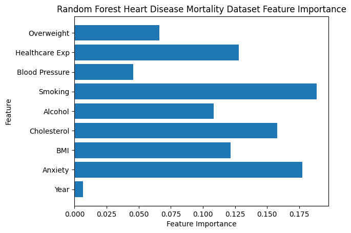

```python
# Use random forest regressor to fit on data and get feature importance with 100 decision trees and MSE criterion
rf_reg = RandomForestRegressor(n_estimators=100, criterion="squared_error")
rf_reg = rf_reg.fit(X, y)

# Set feature importance plot axis labels
plt.figure()
plt.title('Random Forest Heart Disease Mortality Dataset Feature Importance')
plt.xlabel('Feature Importance')
plt.ylabel('Feature')

# Create horizontal bar graph with features on the y-axis and the importance of each feature as the width
plt.barh(y=X.columns, width=rf_reg.feature_importances_)
plt.show()
```

Based on the above bar graph, it appears that smoking and anxiety are the two most important features in accurately predicting heart disease mortality rate while blood pressure and % of overweight adults and year are the three least important features with year barely having any importance. The top 2 features make sense but the last 3 features are questionable. However, one thing to keep in mind is that this feature importance plot is generated from the whole dataset so it might make more sense to find the importance of each feature for each country and use that information to compute the mean importance of each feature across all countries. We also should find the MSE and R^2 scores of the random forest regressor, which learns from 80% randomly sampled training data, on 20% randomly sampled test data to show that the random forest's predictions are very close to the expected heart disease mortality rates.

```
Random Forest Regressor MSE Score on Test Data:  0.004283175263582602
Random Forest Regressor R2 Score on Test Data:  0.7548568840578384
```

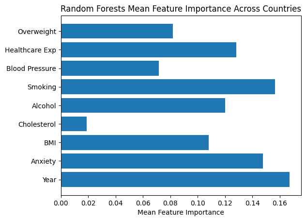

```python
# Creating second random forest regressor to run on randomly sampled training and test data and measure how strong of a fit random forest is for predicting heart disease mortality rates
rf_reg2 = RandomForestRegressor(n_estimators = 100, criterion = "squared_error")
rf_reg2 = rf_reg2.fit(trainX, trainY)
rfTestX = tempX
rfTestY = tempY
rf_yTestPred = rf_reg2.predict(rfTestX)
rfMSE = mean_squared_error(rfTestY, rf_yTestPred)
rf_r2 = r2_score(rfTestY, rf_yTestPred)
print("Random Forest Regressor MSE Score on Test Data: ", rfMSE)
print("Random Forest Regressor R2 Score on Test Data: ", rf_r2)

# Create data frame that will store feature importances for all countries
featureImportancesDf = pd.DataFrame(columns = ['Country', 'Year', 'Anxiety', 'BMI', 'Cholesterol', 'Alcohol', 'Smoking', 'Blood Pressure', 'Healthcare Exp', 'Overweight'])
featureImportancesDf['Country'] = heart_disease_death_rates['Country'].unique()
countryIndex = 0

# Iterate through each country once
for country in featureImportancesDf['Country']:
    # Create and populate data frames for input features and output feature of the current country
    countryX = pd.DataFrame(columns = ['Year', 'Anxiety', 'BMI', 'Cholesterol', 'Alcohol', 'Smoking', 'Blood Pressure', 'Healthcare Exp', 'Overweight'])
    countryY = heart_disease_death_rates[heart_disease_death_rates['Country'] == country]['Heart Disease Mortality Rate']

    for feature in countryX.columns:
        countryX[feature] = heart_disease_death_rates[heart_disease_death_rates['Country'] == country][feature]

    # using random forest regressor to get feature importances
    rf_reg3 = RandomForestRegressor(n_estimators=100, criterion="squared_error")
    rf_reg3 = rf_reg3.fit(countryX, countryY)
    countryFeatureImportances = rf_reg3.feature_importances_.tolist()

    # Put the importance of each of this country's features into the values of the features corresponding to the country's row
    j = 0
    for feature in countryX.columns:
        featureImportancesDf.loc[countryIndex, feature] = countryFeatureImportances[j]
        j += 1

    countryIndex += 1

# Compute list containing mean feature importance of 9 input feature
meanFeatureImportances = []
for feature in X.columns:
    meanFeatureImportances.append(featureImportancesDf[feature].mean(axis = 0))

# Set mean feature importance plot axis label and title
plt.figure()
plt.title('Random Forests Mean Feature Importance Across Countries')
plt.xlabel('Mean Feature Importance')

# Create horizontal bar graph with features on the y-axis and each mean feature importance as the width
plt.barh(y=X.columns, width=meanFeatureImportances)
plt.show()
```

Based on the above results, the Random Forest Regressor has an extremely low MSE and the R^2 value is between 0.74-0.78, which indicates that 74%-78% of the heart disease mortality output data is correctly explained by the random forest predictions. This demonstrates that the Random Forest Regressor is significantly better than the linear regression and will provide reliable insights. However, we will also test other models (decision trees, K-Nearest Neighbors) to identify the best one. The mean feature importance plot has major differences compared to the previous feature importance plot. Here, year, anxiety, smoking, and healthcare expenditure are the 4 most important features with relatively close mean importances. BMI and alcohol then come next being close to each other, overweight and blood pressure follow, and we finally have cholesterol as the least important feature. While this plot does show us the most important features that the random forest regressor identifies when training, it might be a good idea to create a bar chart that shows the number of countries that have their most important as the current feature across all features (excluding year) to verify this matches the trend we observe in the random forest mean importance plot.

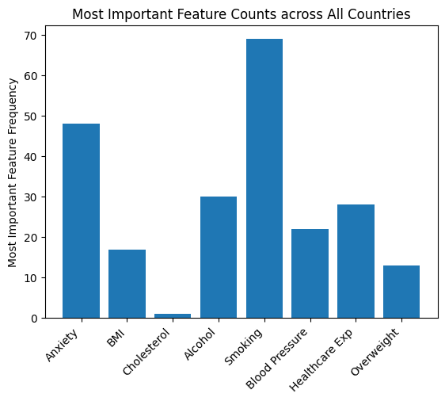

```python
# Make a copy of the feature importances data frame for the heart disease mortality data set and drop the country and year,
# columns as the country isn't a feature and the year being the most important feature of a country doesn't make sense
featureImportancesDfCopy = featureImportancesDf.copy()
featureImportancesDfCopy.drop('Country',axis=1,inplace=True)
featureImportancesDfCopy.drop('Year',axis=1,inplace=True)

# Create dict that has features as keys and the number of countries with that feature as their most important feature for each feature as values
mostImportantFeaturesCountsDict = dict()
for feature in featureImportancesDfCopy.columns:
    mostImportantFeaturesCountsDict[feature] = 0

# Iterate through each row (country)
for index, row in featureImportancesDfCopy.iterrows():
    currentMostImportantFeature = featureImportancesDfCopy.columns[0]
    # Find feature in current row that has highest feature importance and increment count of that feature
    for feature in featureImportancesDfCopy.columns:
        if row[feature] > row[currentMostImportantFeature]:
            currentMostImportantFeature = feature
    mostImportantFeaturesCountsDict[currentMostImportantFeature] += 1

plt.title('Most Important Feature Counts across All Countries')
plt.ylabel('Most Important Feature Frequency')

# create horizontal bar graph with features (without year) on the y-axis and the importance of each feature as the width
plt.bar(x=featureImportancesDfCopy.columns, height=list(mostImportantFeaturesCountsDict.values()))
plt.xticks(rotation=45, ha="right")
plt.show()
```

The results from the above bar chart that shows the counts of countries that have each feature as their most important feature are consistent with the mean importance plot we get from the random forest regressor. Here, smoking and anxiety have the highest number of countries that have them as their most important features and in the mean importance plot, these 2 features have the highest importance values (excluding year). Cholesterol very clearly also has the lowest count of countries that have it as their most important feature similar to it having the least importance from the mean feature importance plot and the rest of the features are relatively close in similarity between these two plots. This bar chart is an accurate reflection of what we got from the random forest regressor mean feature importance plot, meaning we can rely upon the insights from both these plots.

Another step that might help us further examine feature importance is to create a data frame that ranks the features from highest to least importance for each country (1st to 8th most important features). That way, we know what feature has the greatest effect (positive or negative depending upon feature) upon heart disease mortality rate in each country and what feature has the least importance (impact) upon the heart disease mortality rate in each country (may entail being improved or addressed depending upon the feature to reduce heart disease mortality rate). The code below will generate this data frame.

```python
# Create a new data frame that will store the feature rankings of each country and appropriate column names
countryFeatureRankingsDf = pd.DataFrame(columns = ['Country', '1st Important Feature', '2nd Important Feature', '3rd Important Feature', '4th Important Feature',
                         '5th Important Feature', '6th Important Feature', '7th Important feature', '8th Important Feature'])

# Iterate through every row of the feature importances dataframe
for index, row in featureImportancesDfCopy.iterrows():
    # Add name for current country to new data frame
    countryFeatureRankingsDf.loc[index, 'Country'] = featureImportancesDf.loc[index, 'Country']
    # Create dict that stores the 8 features (keys) and their values for the current row from the importances data frame
    featureValsDict = dict()
    for feature in featureImportancesDfCopy.columns:
        featureValsDict[feature] = row[feature]

    # Sort the features (keys) by their values in the feature vals dict in descending order
    sortedFeatureValsDict = dict(sorted(featureValsDict.items(), key=lambda x:x[1],  reverse = True))

    # Add sorted feature names (most to least important) to columns in data frame
    featureIndex = 0
    for feature in countryFeatureRankingsDf.columns[1:]:
        features = list(sortedFeatureValsDict.keys())
        currentFeature = features[featureIndex]
        countryFeatureRankingsDf.loc[index, feature] = currentFeature
        featureIndex += 1

countryFeatureRankingsDf
```

|  | Country | 1st Important Feature | 2nd Important Feature | 3rd Important Feature | 4th Important Feature | 5th Important Feature | 6th Important Feature | 7th Important feature | 8th Important Feature |
| --- | --- | --- | --- | --- | --- | --- | --- | --- | --- |
| 0 | Afghanistan | Alcohol | Healthcare Exp | Anxiety | Overweight | BMI | Smoking | Blood Pressure | Cholesterol |
| 1 | African Region (WHO) | Blood Pressure | Alcohol | Anxiety | BMI | Healthcare Exp | Overweight | Smoking | Cholesterol |
| 2 | Albania | Blood Pressure | Anxiety | Healthcare Exp | Smoking | Overweight | Alcohol | BMI | Cholesterol |
| 3 | Algeria | Anxiety | Healthcare Exp | Smoking | Overweight | Blood Pressure | Alcohol | BMI | Cholesterol |
| 4 | American Samoa | Healthcare Exp | Smoking | Anxiety | BMI | Alcohol | Overweight | Blood Pressure | Cholesterol |
| ... | ... | ... | ... | ... | ... | ... | ... | ... | ... |
| 223 | World Bank Lower Middle Income | Alcohol | Anxiety | Healthcare Exp | BMI | Cholesterol | Smoking | Blood Pressure | Overweight |
| 224 | World Bank Upper Middle Income | Smoking | Anxiety | Alcohol | Healthcare Exp | BMI | Cholesterol | Blood Pressure | Overweight |
| 225 | Yemen | BMI | Smoking | Healthcare Exp | Cholesterol | Alcohol | Anxiety | Blood Pressure | Overweight |
| 226 | Zambia | Healthcare Exp | Smoking | Anxiety | Alcohol | BMI | Cholesterol | Blood Pressure | Overweight |
| 227 | Zimbabwe | Smoking | Anxiety | Alcohol | Healthcare Exp | Cholesterol | BMI | Blood Pressure | Overweight |

228 rows × 9 columns

Now that we have create the data frame above that shows the rankings of the features for each country, we can now plot a map that shows the most important feature for each of the 228 countries/development zones using the chloropleth function from the plotly.express module. This will help us visualize what is the most significant feature that impact heart disease mortality rate within each country with a legend of different colors for each feature. To actually map the values onto the map, we need the geospatial data of the countries, which can be found by downloading countries.geo.json from the World Geo Repository via [this link](https://www.kaggle.com/datasets/chapagain/country-state-geo-location). If you would like to learn more about how maps are made via plotly, feel free to read [this doc](https://plotly.com/python/choropleth-maps/). This map only contains 193 countries so the other 35 development zones and non-country states will not be included here. One thing to note is that since an interactive map can't appear within an HTML file, we had to take a screenshot of our heatmap to be able to show it in the Jupyter Notebook HTML.

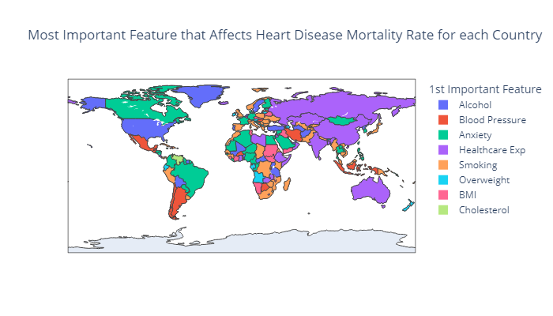

```python
# Read in the geospatial data from the countries JSON file
filePath = r'data/countries.geo.json'

# Create choropleth that shows 1st most important feature that affects heart disease mortality rate
fig = plex.choropleth(countryFeatureRankingsDf, geojson=filePath, color="1st Important Feature", locations="Country",
                    locationmode = 'country names', featureidkey="feature.properties.name",
                    title="Most Important Feature that Affects Heart Disease Mortality Rate for each Country", width = 700, height = 400)

# The interactive map does not correctly show on the HTML, so instead we took a screenshot (PNG) was taken of it and it is shown below
Image(filename = "most_important_feature_countries.png")

# This would show the interactive map (as shown in the HTML) in the notebook in your local IDE
#fig.show()
```

Another aspect that is worth exploring is determining what feature each country needs to improve upon to minimize their heart disease mortality rates. For our tutorial, we can define this as the least important feature as this is the one least concentrated upon and that should be further evaluated to determine whether addressing it will have a positive impact on heart disease mortality rate. In the map below, we can see that most countries have their overweight population, cholesterol, and blood pressure rates as their least important features, which means they should invest more funding to do an assessment of their impact in greater depth to determine what health policy decisions can be implemented to improve heart disease mortality rate via these factors. This is especially important if these three factors are found to have a significant effect. One thing to note is that there are many ways to define the primary feature to improve upon but for the sake of this tutorial, we will make the definition simpler.

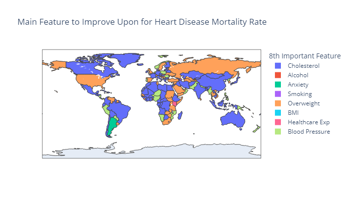

```python
# Read in the geospatial data from the countries JSON file
filePath = r'data/countries.geo.json'

# Create choropleth that indicates feature to be most improved upon that affects heart disease mortality rate in each country
fig = plex.choropleth(countryFeatureRankingsDf, geojson=filePath, color="8th Important Feature", locations="Country",
                    locationmode = 'country names', featureidkey="feature.properties.name",
                    title="Main Feature to Improve Upon for Heart Disease Mortality Rate", width = 700, height = 400)

# The interactive map does not correctly show on the HTML, so instead we took a screenshot (PNG) was taken of it and it is shown below
Image(filename = "feature-to-improve-upon.png")

#fig.show()
```

#### **KNN (K-Nearest-Neighbors)**

[figure not shown]

```
KNN Regressor MSE Score on Test Data:  0.019130811644500312
KNN Regressor R2 Score on Test Data:  -0.09493226133190946
```

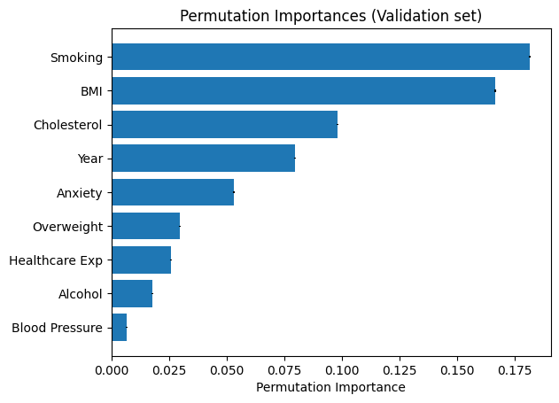

|  | Country | KNN_Score |
| --- | --- | --- |
| 0 | Afghanistan | 5.196284e-05 |
| 1 | African Region (WHO) | 7.138436e-06 |
| 2 | Albania | 2.810171e-06 |
| 3 | Algeria | 3.605194e-05 |
| 4 | American Samoa | 3.612587e-07 |
| ... | ... | ... |
| 223 | World Bank Lower Middle Income | 2.209181e-05 |
| 224 | World Bank Upper Middle Income | 4.637130e-05 |
| 225 | Yemen | 5.186257e-06 |
| 226 | Zambia | 5.895027e-06 |
| 227 | Zimbabwe | 6.164120e-06 |

228 rows × 2 columns

```
Feature: Smoking, Importance: 0.012015280359403913
Feature: Cholesterol, Importance: 0.00779355898791112
Feature: BMI, Importance: 0.006522864263609263
Feature: Alcohol, Importance: 0.004253525327059249
Feature: Healthcare Exp, Importance: 0.001521408211850983
Feature: Year, Importance: 0.0
Feature: Overweight, Importance: -0.002703406606742287
Feature: Blood Pressure, Importance: -0.002791150900741557
Feature: Anxiety, Importance: -0.0033201594211852425
```

```python
# Create and fit 5-nearest neighbors KNN regressor on training X and y data
knn_reg = KNeighborsRegressor(n_neighbors=5)
knn_reg.fit(trainX, trainY)

# Making predictions on test X data and compute MSE and R2 scores between test predictions and expected outputs
knn_yTestPred = knn_reg.predict(rfTestX)
knnMSE = mean_squared_error(rfTestY, knn_yTestPred)
knn_r2 = r2_score(rfTestY, knn_yTestPred)

print("KNN Regressor MSE Score on Test Data: ", knnMSE)
print("KNN Regressor R2 Score on Test Data: ", knn_r2)


# Compute permutation importances
perm_importance = permutation_importance(knn_reg, validX, validY, n_repeats=30, random_state=42)

# Extract importances and their standard deviations
importances = perm_importance.importances_mean
std = perm_importance.importances_std

# Sort the features based on importance
sorted_idx = importances.argsort()

# Plotting the features
plt.title('Permutation Importances (Validation set)')
plt.barh(validX.columns[sorted_idx], importances[sorted_idx], yerr=std[sorted_idx], align='center')
plt.xlabel('Permutation Importance')
plt.show()


# Computing knn score for each country
country_knn_scores = []

for country in featureImportancesDf['Country']:
    countryX = pd.DataFrame(columns = ['Year', 'Anxiety', 'BMI', 'Cholesterol', 'Alcohol', 'Smoking', 'Blood Pressure', 'Healthcare Exp', 'Overweight'])
    countryY = heart_disease_death_rates[heart_disease_death_rates['Country'] == country]['Heart Disease Mortality Rate']

    for feature in countryX.columns:
        countryX[feature] = heart_disease_death_rates[heart_disease_death_rates['Country'] == country][feature]

    knn_reg_country = KNeighborsRegressor(n_neighbors=5)
    knn_reg_country.fit(countryX, countryY)
    country_yPred = knn_reg_country.predict(countryX)

    mse_country = mean_squared_error(countryY, country_yPred)
    country_knn_scores.append((country, mse_country))


# Creating new data frame that scores each country and its KNN score
country_scores_df = pd.DataFrame(country_knn_scores, columns=['Country', 'KNN_Score'])
display(country_scores_df)


#Fit KNN regressor on X and y data and create feature scores dict
original_score = knn_reg.score(X, y)
feature_scores = {}

# Iterate through each feature
for feature in X.columns:

    X_perturbed = X.copy()

    # Add random noise to the feature
    X_perturbed[feature] = X_perturbed[feature] + np.random.normal(0, 0.01, size=X_perturbed[feature].shape)

    # Measure the score after perturbation
    perturbed_score = knn_reg.score(X_perturbed, y)

    # The change in the score can be an indicator of the feature's importance
    feature_scores[feature] = original_score - perturbed_score

# Sort the features based on the score change
sorted_features = sorted(feature_scores.items(), key=lambda x: x[1], reverse=True)

# Printing out feature importances
for feature, score in sorted_features:
    print(f"Feature: {feature}, Importance: {score}")
```

#### **Decision Tree**

The next model we will explore is the Decision Tree Regressor. This model works by selecting the best splits to divide a dataset by. It uses an algorithm that prioritizes the selection of splitting features with polar, non-mixed, outcomes.

The first thing we will do, is split our data into testing and training sets. This way, have a chunk of "new" data we can test the effectiveness of our model with after we are finished training it.

```python
# Create the decision tree regressor
from sklearn.tree import DecisionTreeRegressor
# we will use this to split up our dataframe
from sklearn.model_selection import train_test_split
# we will use this to test how good our model is
from sklearn.metrics import mean_squared_error
# help visualize the tree
from sklearn.tree import plot_tree
from sklearn.datasets import make_regression
from sklearn.metrics import r2_score

# the random seed we will use
seed = 42

# Split the DataFrame into train, validation, and test sets
train_df, test_df = train_test_split(heart_disease_death_rates, test_size=0.2, random_state=seed)


# Print the shapes of the sets
print("Original set shape:",heart_disease_death_rates.shape)
print("Train set shape:", train_df.shape)
print("Test set shape:", test_df.shape)
```

```
Original set shape: (1368, 11)
Train set shape: (1094, 11)
Test set shape: (274, 11)
```

Next, we train our training set. This is when the actual decision tree is formed. Now that the tree is formed, the data that we input (in this case X_test) will be conditionally evaluated until it reaches the leaves of the tree structure, where it will then output the constant value of this final segment. This constant value becomes out prediction. Once we have our predictions we can use terms like figures like mean squared error, and R-square score to evaluate how effective our model is as making predictions, relative to other models. In our case, the MSE is low and the R2 score is 0.43, which means 43% of the variance in the dataset is explained, which is better than multivariate linear regression and KNN but still not as effective as random forests.

```python
# Separate features and target
X_train = train_df[['Year', 'Anxiety', 'BMI', 'Cholesterol', 'Alcohol',
'Smoking', 'Blood Pressure', 'Healthcare Exp', 'Overweight']]
y_train = train_df["Heart Disease Mortality Rate"]
X_test = test_df[['Year', 'Anxiety', 'BMI', 'Cholesterol', 'Alcohol',
'Smoking', 'Blood Pressure', 'Healthcare Exp', 'Overweight']]
y_test = test_df[["Heart Disease Mortality Rate"]]

# Create and fit a DecisionTreeRegressor model
model = DecisionTreeRegressor(random_state=42)
model.fit(X_train, y_train)

# Make predictions on the test set
y_pred = model.predict(X_test)

# Calculate the mean squared error
mse = mean_squared_error(y_test, y_pred)
r2 = r2_score(y_test, y_pred)
print("Mean Squared Error:", mse)
print("R-squared score:", r2)
```

```
Mean Squared Error: 0.009954133889098413
R-squared score: 0.43028541959826494
```

When we plot this data, we notice that predictions and actual data don't always match up. There are several instances where the prediction is significantly different from the real outcome. But value of a regressor is in its ability to generalize, rather than over fit data.

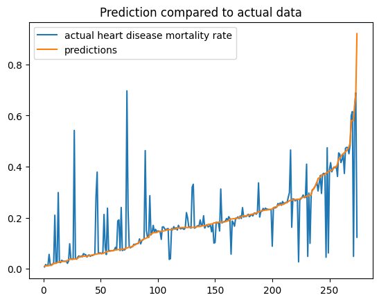

```python
y_test = y_test['Heart Disease Mortality Rate'].values
# Get the indices that would sort the 'values' array
sorted_indices = np.argsort(y_pred)


# Sort both arrays using the sorted indices
sorted_y_test = y_test[sorted_indices]
sorted_y_pred = y_pred[sorted_indices]

x = np.arange(1, 275)
plt.title("Prediction compared to actual data")
plt.plot(x,sorted_y_test,label='actual heart disease mortality rate')
plt.plot(x,sorted_y_pred,label='predictions')
plt.legend()
plt.show()
```

We can also use our trained model to tell us which features had the biggest impact on heart disease mortality, with smoking being the biggest predictor by a huge margin.

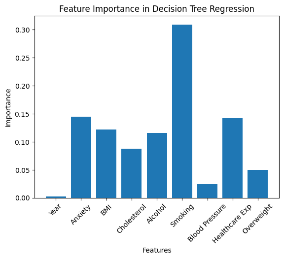

```python
feature_importances = model.feature_importances_
plt.title("Feature Importance in Decision Tree Regression")
plt.bar(['Year', 'Anxiety', 'BMI', 'Cholesterol', 'Alcohol',
'Smoking', 'Blood Pressure', 'Healthcare Exp','Overweight'],feature_importances)
plt.xlabel('Features')
plt.ylabel('Importance')
plt.xticks(rotation=45)
plt.show()
```

Typically, decision trees are used in classification problems of a few features, and smaller datasets. One strength of them is that they don't require large amounts of data to make accurate predictions. However, in our example we have 9 features and over 1000 entries. This results in several levels to the tree. For this reason we have decided to use a visual that shortens our tree to only 4 levels. Note how each node of the tree is able to handle continuous values, by classifying them as lesser than or greater than the value chosen as the split.

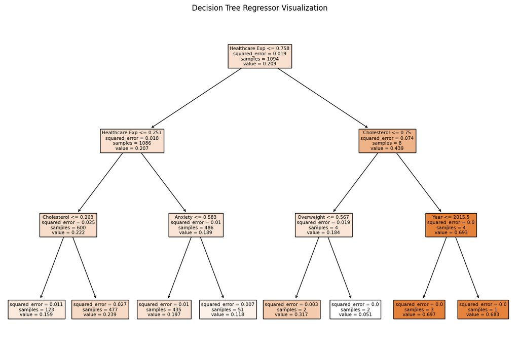

```python
model_draw = DecisionTreeRegressor(max_depth=3, random_state=42)
model_draw.fit(X_train, y_train)

# Make predictions on the test set
y_pred = model_draw.predict(X_test)
# Visualize the decision tree
plt.figure(figsize=(15, 10))
plot_tree(model_draw, filled=True, feature_names= ['Year', 'Anxiety', 'BMI', 'Cholesterol', 'Alcohol', 'Smoking', 'Blood Pressure', 'Healthcare Exp', 'Overweight','Heart Disease Mortality Rate'])
plt.title("Decision Tree Regressor Visualization")
plt.show()
```

## **Conclusions (Insights & Policy Decision)**

[figure not shown]

In general, reducing heart disease death rate is one of many major global health issues and the scope of this problem is larger than what we have shown in this tutorial. Our objective with this tutorial was to explore and show the importance of this issue while also providing an interactive, engaging, and exciting example of the data science pipeline for any reader. We truly hoped you gained lots of valuable insight by reading our tutorial. If you are interested in further exploring this issue or global health in general, feel free to visit the [Global Health Observatory](https://www.who.int/data/gho) page of the WHO, which has data regarding many global health indicators.